# General Assignment 2

Rcourse2023 Team

February 9th, 2023

# Initial Notes

This is the second General Assignment of the Rcouse 2023.

You are required to submit this assignment to get a final grade. Remember The final grade is calculated numerically: 20% weekly assignments (top 10 grades), 40% General assignment 1 and 40 General assignment 2.

**Common instructions:**

- Add your name (Latin characters only) at the beginning of this document for **author**, but don’t modify the rest of the upper part of the document so that the html document renders appropriately.
- Use the given spaces to write your code, don’t change the order of chunks of code, and avoid editing the instructions.
- Answer the questions given throughout the assignment at the **very bottom** section of the document.
- When you are finished and ready to submit, use the **knitr** button above the Rstudio IDE to render (create) the html document to check that it is done correctly.
- IMPORTANT: Omit or comment lines that INSTALL packages and that PRINT unnecessary information like entire tables of data. Do not include local file PATHS.
- **Save** your results in a specific named variable when instructed. Failing to do so will result in penalties.
- You have until midnight of the deadline day to submit your answers.

Good luck!

# Setup

## Install and load the following required packages

- From CRAN:
  - pheatmap
  - ggplot
  - magrittr
  - dplyr
- From Bioconductor:
  - tximport
  - DESeq2
  - LSD
  - SummarizedExperiment

> You may have to install some of these packages first.  
> Do not include installation commands in your submitted answer (at the very least comment them using ‘#’ at the start of line)  
> A penalty will be applied if you ignore this.

*Please, report any problems with package installation ASAP!*

# 1 TASK1: DESeq analysis of APEX-tagged genes

In this assignment, you will analyze RNA-seq data from a recent [paper](https://elifesciences.org/articles/29224). In this work, the authors developed a method termed APEX-RIP, which maps transcriptomes to sub cellular compartments based on proximity to a specific protein.

The four proteins used in this study are markers from different cellular locations:

1. A mitochondrial protein (Mito),
2. An ER membrane protein (KDEL-HRP),
3. A nuclear localization sequence (NLS),
4. A nuclear export sequence (NES).

For each of these fusions, RNAs labelled with biotin (“RIP”) were compared to a non-labelled background (“Input”), each with 2-3 replicates. The RNA-seq data were quantified using RSEM and gene annotations taken from RefSeq. The file “rsem_files_ex.txt” consists in a table, *a.k.a* Design Matrix, assigning each file within the zipped archive has a specific condition and replicate number.

*Notes:*

- RSEM is an accurate and user-friendly software tool for quantifying transcript abundances from RNA-Seq data. RSEM implements an algorithm to assign reads to the isoforms from which they are more likely to be originated.
- Therefore the transcript level is not to be mistaken for read counts. It is a quantitative estimation of transcript abundance given RNA-seq data.

## 1.1 Load RSEM data

### 1.1.1 Read the table “rsem_files_ex.txt” into an object called `ftab`.

This file catalogues RNA-seq experiments in the form of a table with 3 columns:  
(i) The RSEM output file  
(ii) Condition tested for each experiment  
(iii) The number of the replicate

### 1.1.2 Load RSEM files

Load all the RSEM files into a variable called `rse` using tximport() and the `ftab`object.

*Note:*

> To prevent reloading data if you made a mistake, we suggest creating a backup copy of the `rse` to an object called `rse.bak`. If somehow you altered the data, you can restore the original data from the backup running the following command: `rse <- rse.bak`  
> Alternatively, you could `save()` the object `rse` to an RData file. Then read the file with the function `load()` whenever you need to restore data.

### 1.1.3 Filter out transcripts that their **minimum** length is **shorter** than 300 bases

You can make a logical vector to indicate which rows correspond to transcripts with a minimum ‘length’ value **greater or equal** to 300 in the corresponding matrix. Then subset the *counts*, *abundance* and *length* data in `rse` (`rse` is a list that includes 3 data sets) with this logical vector.

```r
#--------------------------Starting with reading the tbl-------------------------------
ftab <- read.table("rsem_files_ex.txt")
#--------------------------adding the headers to the table--------------------------------
# colnames(ftab) <- c('files', 'condition', 'replicate', 'replicate_number')
#--------------------------load the RSEM files------------------------------------------
rse <- tximport(ftab$V1, type = "rsem")
# rse <- tximport(files = ftab$files, type = 'rsem')
#--------------------------Backup the original data--------------------------------------
rse.bak <- rse
#--------------------------save the original data----------------------------------------
save(rse, file = "rse.bak.RData")
#---Done with the first part---
#--------------------------Filter out transcripts that their minimum length is shorter than 300 bases--------------------------------
#----creating a logical vector to indicate which rows in the
# rse$length is true for length >= 300
valLength <- apply(rse$length, 1, min) >= 300
#----subset the counts, abundance and length data in rse
rse$counts <- rse$counts[valLength, ]
rse$abundance <- rse$abundance[valLength, ]
rse$length <- rse$length[valLength, ]
#---Done with the second part---
# \U{01f60a}
```

## 1.2 Compare biotin-labeled *vs.* all RNAs across four experiments using DESEQ2

### 1.2.1 Make a data frame with information about the design of all experiments

Using `ftab`, create a data frame `cdat` with 2 columns of factors: 1) condition 2) replicate (with their respective number)

### 1.2.2 Make a DESeqDataSet using the design data frame

*Hint: use the object constructor `DESeqDataSetFromTximport()` with the design* *formula `~condition+replicate` based on `cdat` and `rse`*

**Save** the DESeqDataSet object inside `ds.txi`

*Q1- How many genes do you have in the dataset?*  
**Save** your answer in a variable `ANSWER1`

### 1.2.3 Run the DESeq analysis (*i.e.* differential expression analysis)

*Hint: use `DESeq()` function on the DEseqDataSet object.* *Important! make sure to set the parameter `betaPrior=TRUE`.*

### 1.2.4 **Save** the DESeqDataSet object inside `ds`

### 1.2.5 Filter results for low counts genes.

Make sure to only keep rows for which the sum of counts per row is **greater than 10**. Use the function `counts()` to access count values from a DESeq results object. **Save** the filtered results in an object called `dds`.

*Q2- What fraction (in %) of genes were removed?*

**Save** your answer in a variable `ANSWER2`

*Q3- What fraction (in %) of genes were retained?*

**Save** your answer in a variable `ANSWER3`

## 1.3 Enrichment of differentially expressed genes per compartment

### 1.3.1 Find the number of significantly enriched genes in each compartment

*Significantly enriched genes* should have passed the statistical test on their fold-change expression between conditions (*based on averaged across replicates*) and yielded an *adjusted p-value* below the arbitrary threshold of 0.05.

*The null hypothesis of the test is that the effect of the condition does not affect expression. Hence the fold-change of expression remains at 1 (or 0 on a log scale)*

To access results from a DESeq analysis, use the `results()` function. Make sure to set the threshold for `alpha` to 0.05, specify in the contrast argument what should be compared (conditions or replicates) followed by the names of the conditions/replicates as specified in `cdat`. *Hint: check the help of results for examples*

Extract the results of differential RNA expression for each compartment (Mito, ER, NLS, NES) between biotin-labelled (referred as ‘RIP’) *vs.* their respective background (referred to as ‘Input’).

**Print the summary of each result objects to the console.**

```r
res_Mito <- results(dds, contrast = c("condition", "Mito-APEX2 RIP", "Mito-APEX2 Input"),
    alpha = 0.05)

res_ER <- results(dds, contrast = c("condition", "KDEL-HRP RIP", "KDEL-HRP Input"),
    alpha = 0.05)

res_NLS <- results(dds, contrast = c("condition", "NLS-APEX2 RIP", "NLS-APEX2 Input"),
    alpha = 0.05)

res_NES <- results(dds, contrast = c("condition", "NES-APEX2 RIP", "NES-APEX2 Input"),
    alpha = 0.05)

all_res = c(res_ER, res_Mito, res_NES, res_NLS)
names(all_res) = c("ER", "Mito", "NES", "NLS")

#---Print the summary of each result objects to the console
print(summary(res_Mito))
```

```
##
## out of 19363 with nonzero total read count
## adjusted p-value < 0.05
## LFC > 0 (up)       : 4187, 22%
## LFC < 0 (down)     : 4641, 24%
## outliers [1]       : 0, 0%
## low counts [2]     : 2253, 12%
## (mean count < 3)
## [1] see 'cooksCutoff' argument of ?results
## [2] see 'independentFiltering' argument of ?results
##
## NULL
```

```r
print(summary(res_ER))
```

```
##
## out of 19363 with nonzero total read count
## adjusted p-value < 0.05
## LFC > 0 (up)       : 3719, 19%
## LFC < 0 (down)     : 2997, 15%
## outliers [1]       : 0, 0%
## low counts [2]     : 1502, 7.8%
## (mean count < 2)
## [1] see 'cooksCutoff' argument of ?results
## [2] see 'independentFiltering' argument of ?results
##
## NULL
```

```r
print(summary(res_NLS))
```

```
##
## out of 19363 with nonzero total read count
## adjusted p-value < 0.05
## LFC > 0 (up)       : 3196, 17%
## LFC < 0 (down)     : 4140, 21%
## outliers [1]       : 0, 0%
## low counts [2]     : 2253, 12%
## (mean count < 3)
## [1] see 'cooksCutoff' argument of ?results
## [2] see 'independentFiltering' argument of ?results
##
## NULL
```

```r
print(summary(res_NES))
```

```
##
## out of 19363 with nonzero total read count
## adjusted p-value < 0.05
## LFC > 0 (up)       : 5761, 30%
## LFC < 0 (down)     : 5928, 31%
## outliers [1]       : 0, 0%
## low counts [2]     : 0, 0%
## (mean count < 0)
## [1] see 'cooksCutoff' argument of ?results
## [2] see 'independentFiltering' argument of ?results
##
## NULL
```

```r
#---Done---
# \U{01f60a}
```

### 1.3.2 Barplot: Strong DE genes

Make a barplot with the number of strong differentially expressed genes for each condition.

For each condition, make a logical vector to identify significantly regulated genes within the result object with an adjusted p-value below 0.05 AND **absolute** log2fold-change greater than 1. *You can use the `$` operator to extract data from the result object from the previous step.*

1. Calculate the total number of significantly regulated genes in each compartment.
2. Store those numbers in a vector and use the vector for generating the barplot.
3. Each bar should correspond to one condition; its height would represent the number of genes significantly regulated.
4. Indicate in the title the value for each bar: Mito:__ ER:__ NLS:__ NES:__

**You are asked to extract the number of genes with R commands so do not just write the number**

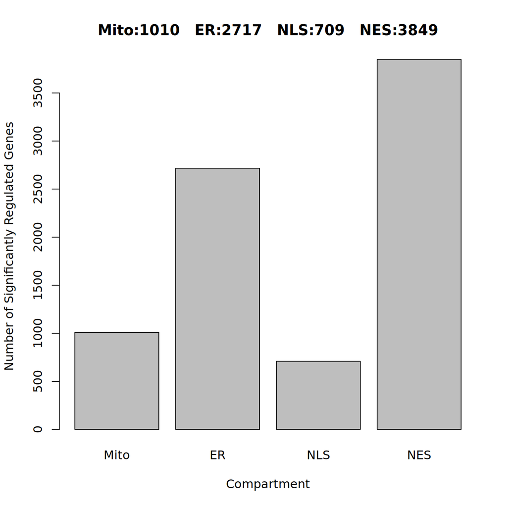

```r
# sum and store the number of strong DE genes if not NA
strong_mito <- res_Mito$padj < 0.05 & abs(res_Mito$log2FoldChange) > 1
strong_er <- res_ER$padj < 0.05 & abs(res_ER$log2FoldChange) > 1
strong_nls <- res_NLS$padj < 0.05 & abs(res_NLS$log2FoldChange) > 1
strong_nes <- res_NES$padj < 0.05 & abs(res_NES$log2FoldChange) > 1

# df for the barplot
significant_genes <- c(sum(strong_mito, na.rm = T), sum(strong_er, na.rm = T), sum(strong_nls,
    na.rm = T), sum(strong_nes, na.rm = T))
names(significant_genes) <- c("Mito", "ER", "NLS", "NES")

# plotting:
barplot(significant_genes, main = paste0("Mito:", significant_genes[1], "   ER:",
    significant_genes[2], "   NLS:", significant_genes[3], "   NES:", significant_genes[4]),
    xlab = "Compartment", ylab = "Number of Significantly Regulated Genes")
```

```r
#---Done---
# \U{01f60a}
```

## 1.4 log2fold-change NLS *vs.* NES heat-scatterplot

Next, we want to evaluate the correlation for expression between different conditions. (*e.g.* NLS *vs.* NES).

Scatterplots are often misinterpreted whenever the density is not taken into account. The `heatscatter()` function from the `LSD` package solves this issue by estimating the points’ density and showing it as a color gradient.

### 1.4.1 HeatScatter plot

Use the log2FoldChange from the result object of both compartments (NLS *vs* NES) within the heatscatter() function. **Make sure to display** the correlation coefficient as the title using the correct parameter of the `heatscatter()` function, *cor = TRUE*.

*Q4- What are the Pearson and Spearman correlation coefficients between the log2-fold* *changes in NLS and NES experiments?*  
> Hint: You can use the `cor()` function to calculate the r coefficient using both the “Spearman” and “Pearson” method  
**Save** your answer in a variable `ANSWER4`

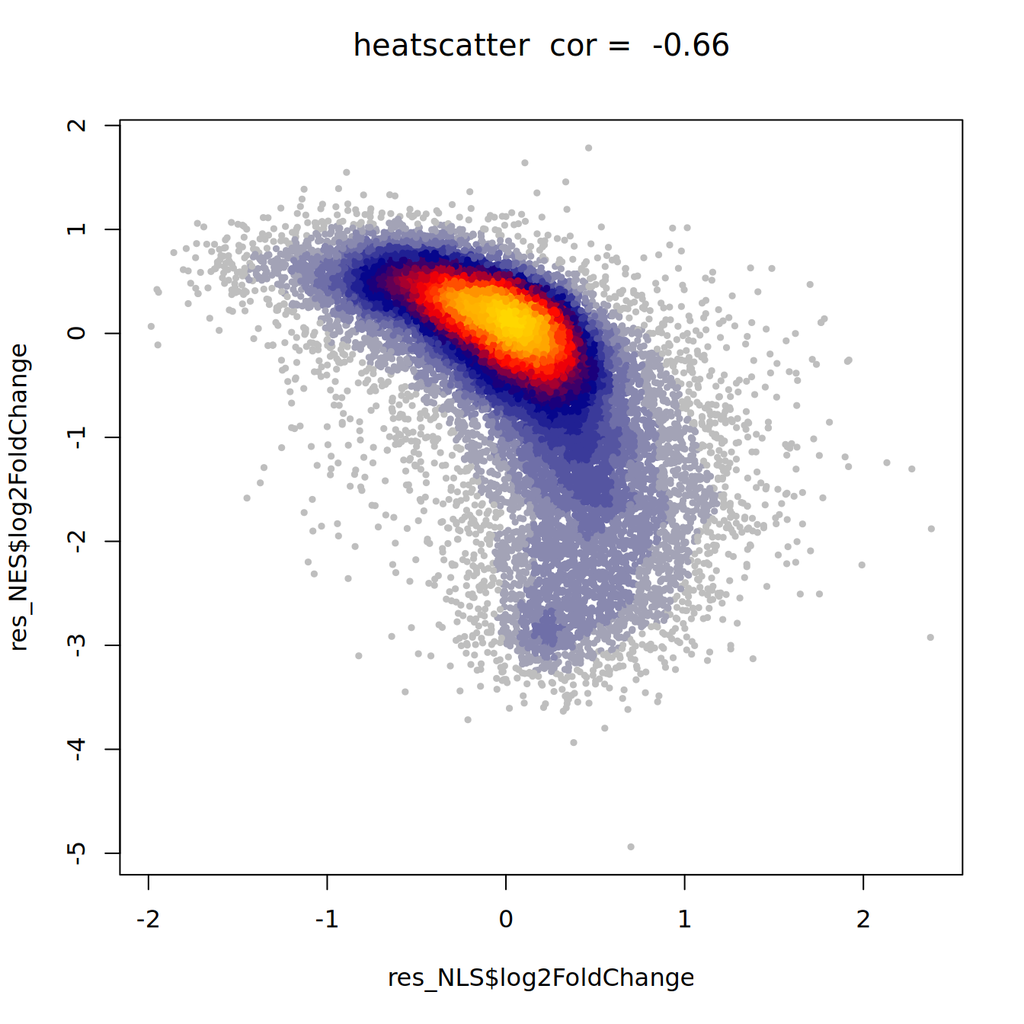

```r
#---HeatScatter plot
heatscatter(res_NLS$log2FoldChange, res_NES$log2FoldChange, cor = TRUE)
```

```r
#---Calculate the Pearson and Spearman correlation coefficients
cor.pearson <- cor(res_NLS$log2FoldChange, res_NES$log2FoldChange, method = "pearson")
cor.spearman <- cor(res_NLS$log2FoldChange, res_NES$log2FoldChange, method = "spearman")

#--- make the answer
ANSWER4 = paste("Pearson:", round(cor.pearson, 4), "Spearman:", round(cor.spearman,
    4))
```

## 1.5 Similarity and hierarchical clustering on log-transformed data

### 1.5.1 log-space counts

Use `rlog()` to transform the DESEQdataset counts into log space and **save** it in a new object called `rld`. *Hint: use `rlog()` function without prior information on samples.* *Check the function’s help for more info.*

### 1.5.2 Summarized Experiment

Convert the log-transformed data `rld` to an object called `SE` of class ‘summarizedExperiment’ *Hint: use the function `assay()`*

### 1.5.3 Euclidean distance between genes

Compute the euclidean distance between differentially expressed genes.

*Hint: use `dist()` to calculate the euclidean distance between samples in the* *summarized experiment results in `SE`.* *You may need to transpose the data, as dist() calculates the distance between rows of the input data*

**Save** inside `dsample`, the variable `SE` as a dist object  
**Save** inside `m.dsample` the variable `dsample` as a matrix object

### 1.5.4 Heatmap: Sample similarity

Create a heatmap of distances between samples: **Distance values should be** **represented with a color gradient.** *For example, darker shades can reflect larger distances between observations, and lighter shades for observations with short distances.*

Set the arguments, cellwidth = 10 and display_numbers = T

*Hint: use `pheatmap()` function with the calculated euclidean distance for both rows and columns clustering calculation*

*Notes:*

> You must convert the distance object to a matrix for `pheatmap()`.  
> Set:
- rownames to reflect the various conditions and replicates.
- clustering_distance_rows = dsample,
- clustering_distance_cols = dsample,
- cellwidth = 10,
- show_colnames = F,
- show_rownames = F,
- fontsize = 5,
- main = “Sample similarity as Euclidean distance”,
- display_numbers = T

This information is accessible in the `rld` object or from the initial `cdat` design data frame from the previous step. *Q5- Based on the heatmap, which sample group is the most distanced from the rest of the treatments?*  
**Save** your answer in a variable `ANSWER5` (10 words maximum)

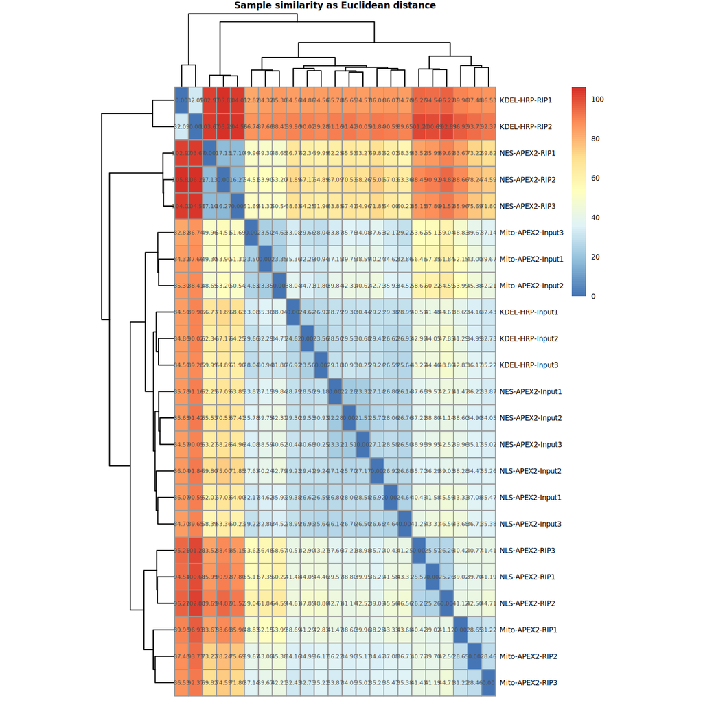

```r
#---log-space counts
rld <- rlog(dds)
#---Summarized Experiment
SE <- assay(rld)
#---Euclidean distance between genes
dsample <- dist(t(SE))
m.dsample <- as.matrix(dsample)

# renames the number of rows in the distance matrix to the condition and
# replicate
rownames(m.dsample) <- paste0(cdat$condition, cdat$replicate)
#----heatmap
pheatmap(m.dsample, rownames = paste0(cdat$condition, cdat$replicate), clustering_distance_rows = dsample,
    clustering_distance_cols = dsample, cellwidth = 10, show_colnames = F, show_rownames = T,
    fontsize = 5, main = "Sample similarity as Euclidean distance", display_numbers = T)
```

```r
ANSWER5 = "the most distanced treatments is KDEL-HRP"
len.ANSWER5 = print(length(unlist(strsplit(ANSWER5, split = " "))))  # DON'T delete!
```

```
## [1] 6
```

# 2 Task3: Data quailty and multiple testing

## 2.1 Load the data

- Load single cell data “caron_mat.RDS” and save it inside a variable `data_sc`.
- Load the meta data “caron_metadata.RDS” and save it inside a variable `metadata_sc`

> Important: Single cell data include information about the expression of genes within multiple cells. **Take** a moment and understand what the rows and columns of `data_sc` represent

```r
data_sc <- readRDS("caron_mat.RDS")
metadata_sc <- readRDS("caron_metadata.RDS")
```

*Q6*: The values in `data_sc` are TPM (transcripts per million)/scaled (Centred Values are: Xi-mean(x))/centered (z-score values i.e. (Xi-mean(x))/sd(x) just like we have learned in the lesson about PCA)?  
Explore the data in the following chunk:

1. Print/Plot maximum 3 plots
2. **Don’t** print text/number/vector/data set information.

*Explain* you answer (30 words **maximum**) and **save** it in a variable `ANSWER6`.

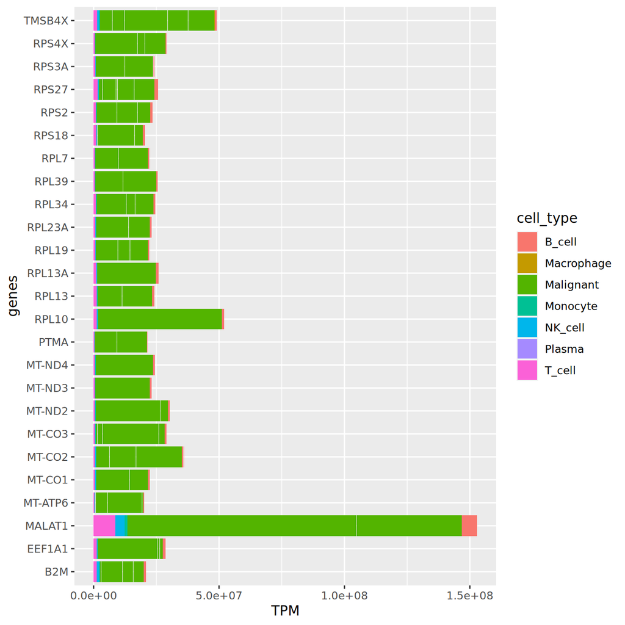

```r
# reshape the data to long format
library(tidyr)
library(reshape)
library(tibble)
dat.long <- data_sc %>%
    as.data.frame() %>%
    rownames_to_column(var = "genes") %>%
    gather(key = "samples", value = "TPM", -genes)
# add to dat.long the metadata base on the sample column match to cell_name in
# the metadata_sc
dat.long <- left_join(dat.long, metadata_sc, by = c(samples = "cell_name"))

# drop all na values
dat.long <- dat.long[!is.na(dat.long$cell_type), ]

#---EDA
# store the most 25 expressed genes in a variable
top25 <- dat.long %>%
    group_by(genes) %>%
    summarise(mean_TPM = mean(TPM)) %>%
    top_n(25, mean_TPM) %>%
    pull(genes)


# barplot of the most 25 expressed genes
dfToPlot <- dat.long %>%
    filter(genes %in% top25)
ggplot(dfToPlot, aes(x = genes, y = TPM, fill = cell_type)) + geom_bar(stat = "identity") +
    coord_flip()
```

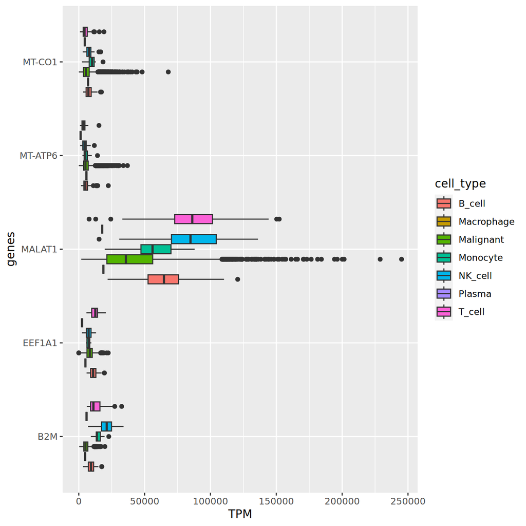

```r
# boxplot of the most 5 expressed genes df of dat.long with od the most 5
# expressed genes
dfToPlot <- dat.long %>%
    filter(genes %in% top25[1:5])
ggplot(dfToPlot, aes(x = genes, y = TPM, fill = cell_type)) + geom_boxplot() + coord_flip()
```

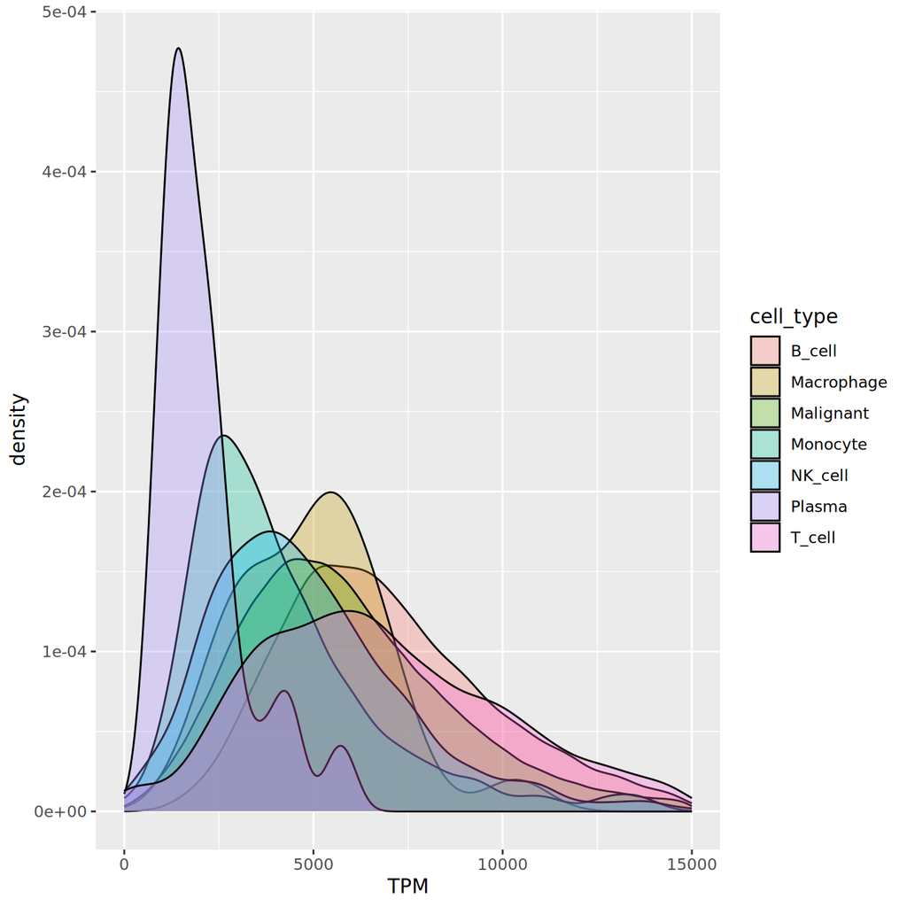

```r
# density plot of the most 50 expressed genes
top50 <- dat.long %>%
    group_by(genes) %>%
    summarise(mean_TPM = mean(TPM)) %>%
    top_n(50, mean_TPM) %>%
    pull(genes)
dfToPlot <- dat.long %>%
    filter(genes %in% top50[1:50])
ggplot(dfToPlot, aes(x = TPM, fill = cell_type)) + geom_density(alpha = 0.3) + xlim(0,
    15000)
```

```r
ANSWER6 = "I chose to plot the most expressed genes in thedatato understand the distribution of the data. The plots show the distribution of the data in the most expressed genes."
len.ANSWER6 = print(length(unlist(strsplit(ANSWER6, split = " "))))  # DON'T delete!
```

```
## [1] 29
```

```r
#---Done---
# \U{01f60a}
```

## 2.2 Log transform the data

1. Log transform the data. First, divide by 10 each value in the data, add 1 to handle zero values and finally, log2 transform.
2. If the data is not centered, center it by deducting the mean of each row from each value in that row.
3. **Save** the log transform data and centered data in a variable `cent_mat`

```r
log_data <- log2((data_sc/10) + 1)
cent_mat <- scale(log_data, center = TRUE, scale = FALSE)
```

## 2.3 QC The data

Calculate the complexity of each cell in the `log_data` (Apply the same calculation from weekly Ex.9).

1. Keep cells with complexity larger than 500 and store the results in a variable `comp_up`

```r
#---Calculate the complexity of each cell in the log_data
comp_up <- apply(log_data, 2, function(x) sum(x > 0))
# getting logical vector of cells with complexity larger than 500
comp_up <- comp_up > 500
```

2. Filter `cent_mat` according to `comp_up`, keep cells with high complexity and **save** the filtered data set in `cent_filt`
3. Filter `metadata_sc` according to `comp_up`, keep cells with high complexity and **save** the filtered data set in `metadata_sc_filt`
4. Filter `log_data` according to `comp_up`, keep cells with high complexity and **save** the filtered data set in `log_data_filt`

```r
cent_filt <- cent_mat[, comp_up]
metadata_sc_filt <- metadata_sc[comp_up, ]
log_data_filt <- log_data[, comp_up]
# print the amouut of cell subsetting and the amouunt of cell removed
# print(paste('The number of cells with high complexity is:', sum(comp_up)))
# print(paste('The number of cells with low complexity is:', sum(!comp_up)))
```

## 2.4 Finding the highly expressed genes

Using `log_data` (unfiltered by complexity) find the top 7000 genes with the highest **mean** expression.

**Save** in a variable `cent_final` a subset of `cent_filt` with only the top 7000 most expressed genes.

```r
#---Finding the highly expressed genes and logic vector of the top 7000 genes
top_genes <- apply(log_data, 1, mean)
top_genes <- order(top_genes, decreasing = T)[1:7000]

# making a subset of cent_filt with only the top 7000 most expressed genes
cent_final <- cent_filt[top_genes, ]
```

## 2.5 Comparing gene expression between Malignant cell to non-Malignant cells

### 2.5.1 Cell classification

Classified cells as Malignant cells or non-Malignant cells

Add a column to `metadata_sc_filt` that is called *Malignant*.  
If the cell type indicates it’s malignant, put “Malignant” in the new column and “non-Malignant” otherwise.

```r
malig_cells <- metadata_sc$cell_type == "Malignant"
metadata_sc_filt$Malignant <- ifelse(metadata_sc_filt$cell_type == "Malignant", "Malignant",
    "non-Malignant")
# drop na values in the metadata_sc_filt malig column
metadata_sc_filt <- metadata_sc_filt[!is.na(metadata_sc_filt$Malignant), ]
```

### 2.5.2 Visualisation of cell classification

Draw a bar plot of the number of malignant cells against non malignant

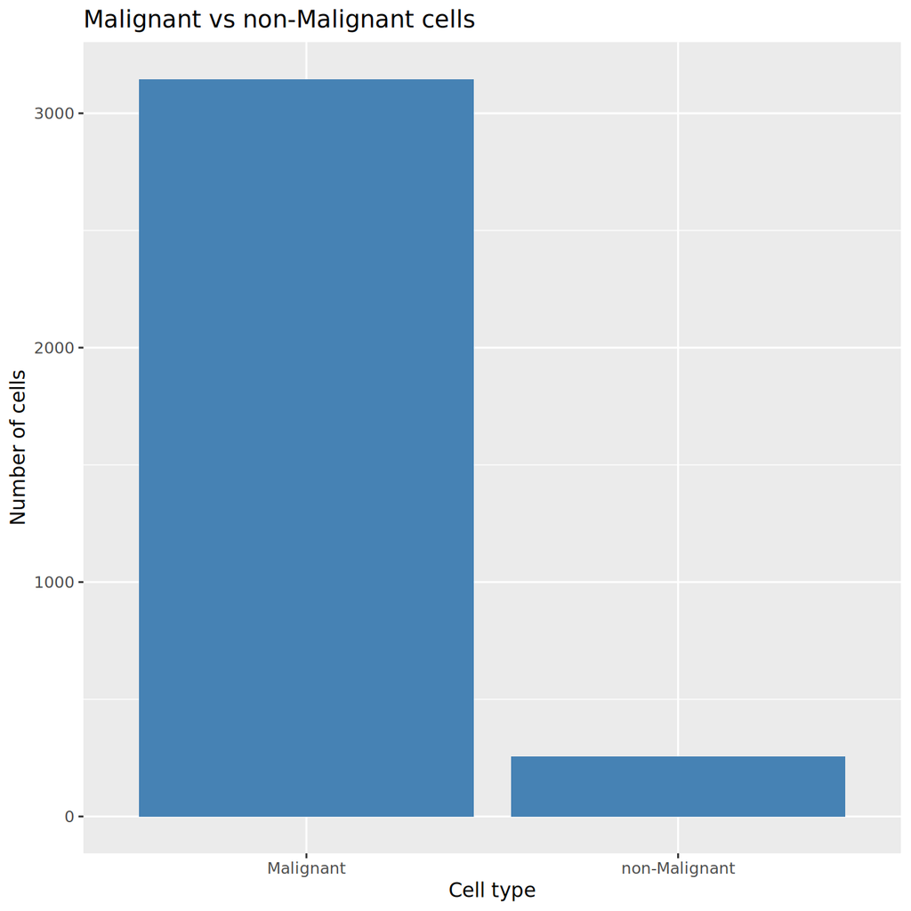

```r
#---Visualisation of cell classification
ggplot(metadata_sc_filt, aes(x = Malignant)) + geom_bar(fill = "steelblue") + labs(title = "Malignant vs non-Malignant cells",
    x = "Cell type", y = "Number of cells")
```